# Neighborhood Score: MapReduce - Report

Jiangtao Xu

9/29/2017

## Execution Environment:

Java Version: 1.8.0_144

OS version: macOS 10.12.6

Processor Name: Intel Core i7

Processor Speed: 2.8GHZ

Total Number of Cores: 4

Memory: 16GB

## Run Big-corpus Problem

However, when run big-corpus based on A1 program, A1 program have to store the corpus on memory to enable program to count letters and neighbors. It’s easily to run out of memory from either sequential or parallel program. In order to compare the performance of Hadoop and other programs, choose data from A1 as input data for both programs.

## For Hadoop Implementation

For hadoop program, I run hadoop 10 times, and collect running time of each iteration.

```r
suppressMessages(library(dplyr))
```

```r
suppressMessages(library(ggplot2))
results <- read.csv("input/books/result.csv",header = FALSE) %>%
  rename(times=V1, implementation=V2) %>%
  mutate(seconds=(as.numeric(times))/1000)
```

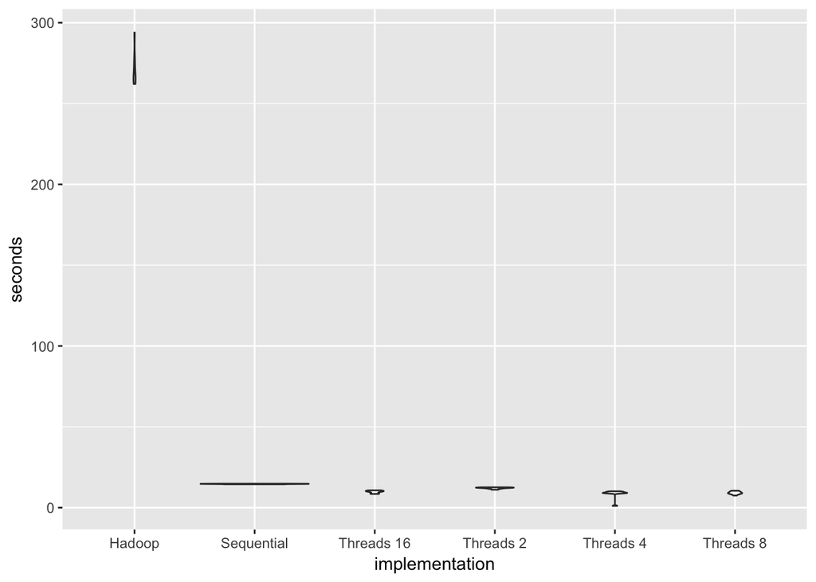

```r
runs <- data.frame(results)
ggplot(runs, aes(x=implementation, y=seconds)) + geom_violin()
```

Let’s take a detailed look at hadoop implementation and sequential implementation:

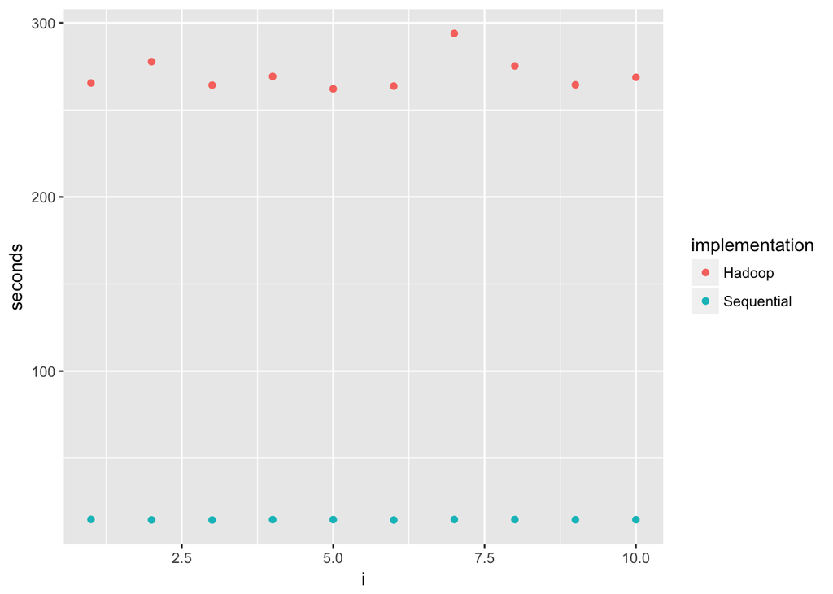

```r
hadoop <-runs %>% filter(implementation=="Hadoop") %>% mutate(i=1:n())
sequential <-runs %>% filter(implementation=="Sequential") %>% mutate(i=1:n())
all <- rbind(sequential,hadoop)
ggplot(all, aes(x=i, y=seconds, color=implementation)) + geom_point()
```

From this plot, we can clearly see that the average of hadoop implementated running time is far larger than the running time of sequential implementation. Besides, running time of hadoop is not stable, which ranges nearly from 260s to 290s

## Conclusion

When running MapReduce program on pseudo-distributed cluster, although it’s parallel impletation, it runs slower than any concurrent program. Indeed, it even slower than sequential implementation.

The reason may be the framework of hadoop, which needs program reading and writing from HDFS, needs more calculation of schdule resource, needs monitoring, running mappper, reducer functions and etc. Compared to sequential and concurrent implementation, resource usage is much higher, which on the other hand pseudo-distributed requires more resource to run the code.

Since resource competition among pseudo-distributed is higher than other two implementation, so the performance of pseudo-distributed cluster is much easily influenced by other running program, which result in the huge variance of running time. For example, once I closed Chrome brower, the MapReduce process became quicker after release the memory of running Chrome.